# Báo cáo phân tích thống kê về đề tài phim

Trần Tiến Đức , Trần Như Thuận, Lương Uy Long và Lê Đỗ Trà My

07/01/2021

```r
library(tidyverse)
library(ggplot2)
```

## Giới thiệu

Internet Movie Database (IMDb - cơ sở dữ liệu điện ảnh trên Internet) là một trang cơ sở dữ liệu trực tuyến về điện ảnh thế giới. Nó cung cấp thông tin về phim, diễn viên, đạo diễn, nhà làm phim… và tất cả những người, công ty trong lĩnh vực sản xuất phim, phim truyền hình và cả trò chơi video. Cơ sở dữ liệu kkhổng lồ này cho phép chúng ta có một cái nhìn tổng quan về lịch sử của từng bộ phim và các yếu tố tác động quan trọng tới những bộ phim điện ảnh của thế giới.

## Dữ liệu

Tập dữ liệu này được lấy từ Kaggle. Trong báo cáo này , chúng ta chỉ quan tâm một số biến có tác động tới sự thành công của một bộ phim điện ảnh.

```r
data <- read.csv("../data/movie_metadata.csv")
# data <- drop_na(data)
data <- data %>%
  # recode empty strings "" by NAs
  na_if("") %>%
  # remove NAs
  na.omit()
data$movie_title <- gsub("Â", "", as.character(factor(data$movie_title)))
data <- data %>%
  mutate(profit = gross - budget,
         return_on_investment_perc = (profit/budget)*100)
str(data)
```

```
## 'data.frame':    3756 obs. of  31 variables:
##  $ movie_id                 : int  1 2 3 4 6 7 8 9 10 11 ...
##  $ color                    : chr  "Color" "Color" "Color" "Color" ...
##  $ director_name            : chr  "James Cameron" "Gore Verbinski" "Sam Mendes" "Christopher Nolan" ...
##  $ num_critic_for_reviews   : int  723 302 602 813 462 392 324 635 375 673 ...
##  $ duration                 : int  178 169 148 164 132 156 100 141 153 183 ...
##  $ director_facebook_likes  : int  0 563 0 22000 475 0 15 0 282 0 ...
##  $ actor_3_facebook_likes   : int  855 1000 161 23000 530 4000 284 19000 10000 2000 ...
##  $ actor_2_name             : chr  "Joel David Moore" "Orlando Bloom" "Rory Kinnear" "Christian Bale" ...
##  $ actor_1_facebook_likes   : int  1000 40000 11000 27000 640 24000 799 26000 25000 15000 ...
##  $ gross                    : int  760505847 309404152 200074175 448130642 73058679 336530303 200807262 458991599 301956980 330249062 ...
##  $ genres                   : chr  "Action|Adventure|Fantasy|Sci-Fi" "Action|Adventure|Fantasy" "Action|Adventure|Thriller" "Action|Thriller" ...
##  $ actor_1_name             : chr  "CCH Pounder" "Johnny Depp" "Christoph Waltz" "Tom Hardy" ...
##  $ movie_title              : chr  "Avatar " "Pirates of the Caribbean: At World's End " "Spectre " "The Dark Knight Rises " ...
##  $ num_voted_users          : int  886204 471220 275868 1144337 212204 383056 294810 462669 321795 371639 ...
```

[output cut: 19 more lines]

```r
#head(data, 10)
```

## Các biến

Mô tả tên các biến và ý nghĩa.

- genres: Thể loại phim
- actor_1_name: Tên diễn viên thứ nhất
- movie_title: Tên phim
- num_voted_users: Số người dùng (trên IMDB) tham gia đánh giá phim
- cast_total_facebook_likes:
- actor_3_name: Tên diễn viên thứ 3
- facenumber_in_poster: Số khuôn mặt có trong poster
- plot_keywords: Các từ khóa về nội dung
- movie_imdb_link: Đường dẫn link phim trên IMDB
- num_user_for_reviews: Số người dùng review phim
- language: ngôn ngữ được sử dụng chính trong phim
- country: Quốc gia sản xuất
- content_rating: Xếp hạng nội dung (Ví dụ: PG-13: Từ 13 tuổi trở lên và cần có sự giám sát của phụ huynh)
- budget: Chi phí sản xuất
- title_year: Năm công chiếu
- actor_2_facebook_likes: Số lượt likes trên facebook về diễn viên thứ 2
- imdb_score: Điểm số trên IMDB
- aspect_ratio: Tỷ lệ khung hình được sử dụng cho phim
- movie_facebook_likes: Số lượt like trên facebook về bộ phim
- profit: Lợi nhuận của bộ phim (Doanh thu - kinh phí sản xuất)
- return_on_investment_perc: Phần trăm lợi nhuận trên kinh phí sản xuất ((Lợi nhuận/Kinh phí) * 100)

## Câu hỏi

Q1. Có sự khác biệt về điểm số (IMDB score ) giữa các phim được đánh giá nội dung là cần có sự giám sát của phụ huynh và những phim được đánh giá nội dung là không có sự giám sát của phụ huynh?

Q2. Ngôn ngữ có ảnh hưởng tới điểm đánh giá của phim hay không?

Q3. Thể loại phim ảnh hưởng tới tđiểm số của bộ phim trên IMDB?

## Hiểu vấn đề

### Xem lướt qua dữ liệu

- Chúng ta sẽ bắt đầu bằng cách trả lời một số câu hỏi về dữ liệu. Trả lời một số câu hỏi đơn giản trên dữ liệu để hiểu hơn về dữ liệu.
  - Trong 10 thể loại phim đầu tiên, số lượng các thể loại trong tập dữ liệu đó ?

```r
genre = data$genres
genre = data.frame(table(genre))
genre = genre[order(genre$Freq,decreasing=TRUE),]
head(genre,10)
```

```
##                           genre Freq
## 533        Comedy|Drama|Romance  147
## 636                       Drama  141
## 478                      Comedy  138
## 508                Comedy|Drama  138
## 581              Comedy|Romance  131
## 700               Drama|Romance  115
## 617        Crime|Drama|Thriller   82
## 186       Action|Crime|Thriller   56
## 172 Action|Crime|Drama|Thriller   50
## 106     Action|Adventure|Sci-Fi   48
```

- Trong 10 bộ phim đầu tiên trong danh sách, có bao nhiêu bộ phim không được sản xuất bởi nước Mỹ?

```r
df <- head(data, 10)
temp <- df[df$country != "USA",]
length(temp)
```

```
## [1] 31
```

```r
# temp
```

- Trong 10 bộ phim đầu tiên trong danh sách, có bao nhiêu phim được sản xuất vào năm 2012?

```r
temp <- df[df$title_year == 2012,]
length(temp)
```

```
## [1] 31
```

- Trong toàn bộ các phim trong dataset, có bao nhiêu loại đánh giá nội dung?

```r
tmp <- factor(data$content_rating)
levels(tmp)
```

```
##  [1] "Approved"  "G"         "GP"        "M"         "NC-17"     "Not Rated"
##  [7] "Passed"    "PG"        "PG-13"     "R"         "Unrated"   "X"
```

### Thiết kế nghiên cứu

#### Xác định loại nghiên cứu

- Xét về mặt đặc tính của nghiên cứu thì nghiên cứu này là nghiên cứu quan sát (observational study) vì chúng ta chỉ quan sát và ghi nhận thực trạng đặc điểm/đặc tính và sự kiện diễn ra trong nghiên cứu mà không có tác động đến đối tượng nghiên cứu.

#### Xác định cách lấy mẫu

- Phương pháp lấy mẫu trong báo cáo này là lấy mẫu ngẫu nhiên đơn giản

## Suy ngẫm về câu hỏi

- Trong bước đầu tiên này, chúng ta nghĩ về câu hỏi và sử dụng trực giác và/hoặc kinh nghiệm của mình để thử và dự đoán kết quả sẽ hiển thị. Sau đó, chúng ta sẽ so sánh những gì chúng ta nghĩ ban đầu với những gì chúng ta thực sự tìm thấy khi chúng ta phân tích dữ liệu.
- Trước khi phân tích dữ liệu và khám phá các câu hỏi, hãy cố gắng dự đoán những gì dữ liệu sẽ thể hiện (sử dụng kinh nghiệm và trực giác của riêng bạn).

## Phân tích dữ liệu

- Trong bước này, chúng ta chọn và tiến hành các phân tích cần thiết để giải quyết câu hỏi hiện tại.

```r
movie_metadata <- data
str(movie_metadata)
```

```
## 'data.frame':    3756 obs. of  31 variables:
##  $ movie_id                 : int  1 2 3 4 6 7 8 9 10 11 ...
##  $ color                    : chr  "Color" "Color" "Color" "Color" ...
##  $ director_name            : chr  "James Cameron" "Gore Verbinski" "Sam Mendes" "Christopher Nolan" ...
##  $ num_critic_for_reviews   : int  723 302 602 813 462 392 324 635 375 673 ...
##  $ duration                 : int  178 169 148 164 132 156 100 141 153 183 ...
##  $ director_facebook_likes  : int  0 563 0 22000 475 0 15 0 282 0 ...
##  $ actor_3_facebook_likes   : int  855 1000 161 23000 530 4000 284 19000 10000 2000 ...
##  $ actor_2_name             : chr  "Joel David Moore" "Orlando Bloom" "Rory Kinnear" "Christian Bale" ...
##  $ actor_1_facebook_likes   : int  1000 40000 11000 27000 640 24000 799 26000 25000 15000 ...
##  $ gross                    : int  760505847 309404152 200074175 448130642 73058679 336530303 200807262 458991599 301956980 330249062 ...
##  $ genres                   : chr  "Action|Adventure|Fantasy|Sci-Fi" "Action|Adventure|Fantasy" "Action|Adventure|Thriller" "Action|Thriller" ...
##  $ actor_1_name             : chr  "CCH Pounder" "Johnny Depp" "Christoph Waltz" "Tom Hardy" ...
##  $ movie_title              : chr  "Avatar " "Pirates of the Caribbean: At World's End " "Spectre " "The Dark Knight Rises " ...
##  $ num_voted_users          : int  886204 471220 275868 1144337 212204 383056 294810 462669 321795 371639 ...
```

[output cut: 19 more lines]

```r
movie_metadata <- movie_metadata[complete.cases(movie_metadata),]
# movie_metadata
```

### 1. Xác định các biến có liên quan

- (Các) biến nào trong số những biến trong tập dữ liệu có liên quan đặc biệt đến câu hỏi hiện tại? (Các) biến này thuộc loại nào (quantitative hay categorical)? Trả lời:
  - Biến content_rating: biến định tính
  - Biến imdb_score: biến định lượng

### 2. Phân tích thăm dò (Exploratory Analysis)

- Bây giờ chúng ta đã xác định và phân loại (các) biến có liên quan, chúng ta sử dụng phương pháp phân tích dữ liệu thăm dò để giúp chúng ta tóm tắt các đặc điểm quan trọng của dữ liệu.

```r
movie_metadata_sample_id <- sample(unique(movie_metadata$movie_id), 1/10 * dim(movie_metadata))
movie_metadata_sample <- subset(movie_metadata, movie_metadata$movie_id %in% movie_metadata_sample_id)
dim(movie_metadata_sample)
```

```
## [1] 375  31
```

```r
content_rating_type <- movie_metadata_sample[, "content_rating"]
content_rating_type <- factor(content_rating_type)
levels(content_rating_type)
```

```
## [1] "Approved"  "G"         "Not Rated" "PG"        "PG-13"     "R"
## [7] "Unrated"
```

```r
length(content_rating_type)
```

```
## [1] 375
```

```r
movie_metadata_sample_copy <- movie_metadata_sample
movie_metadata_sample_copy$content_rating <- as.factor(movie_metadata_sample_copy$content_rating)
levels(movie_metadata_sample_copy$content_rating) <- list("PG" = c("PG", "PG-13"), "Non-PG" = c("Approved", "G", "Not Rated", "R", "Unrated", "X", "GP", "Passed", "NC-17", "M"))
levels(movie_metadata_sample_copy$content_rating)
```

```
## [1] "PG"     "Non-PG"
```

```r
length(content_rating_type[content_rating_type == "PG" | content_rating_type == "PG-13"])
```

```
## [1] 168
```

#### 4. Xác định các biểu đồ và tóm tắt số phù hợp

- Với dạng câu hỏi này, chúng ta sẽ dùng biểu đồ side-by-side boxplot

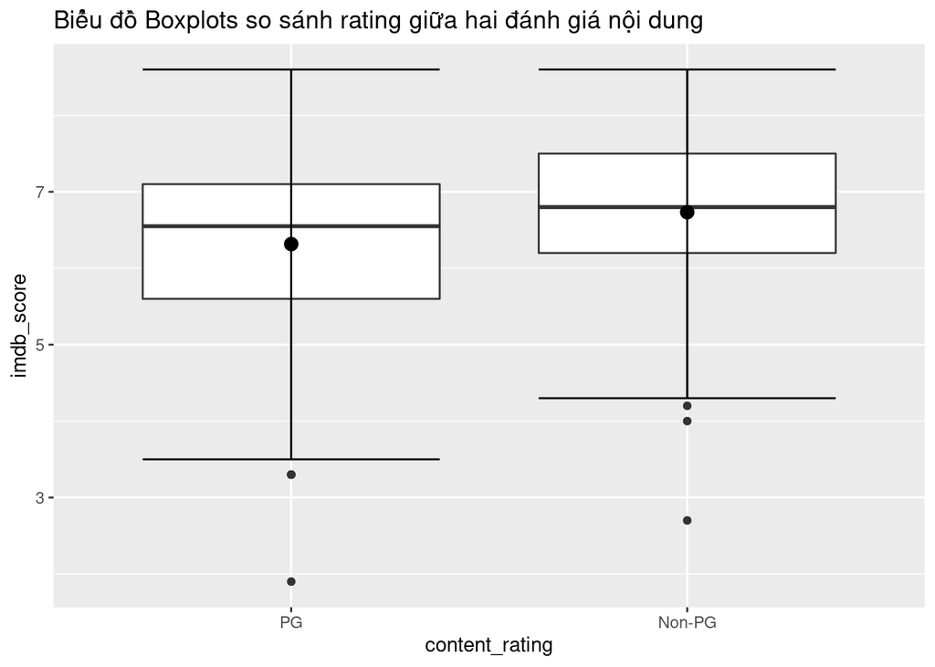

```r
ggplot(data = movie_metadata_sample_copy, aes(x = content_rating, y = imdb_score)) +
  geom_boxplot() +
  stat_boxplot(geom = "errorbar") +
  stat_summary(fun.y = mean, col = "black", geom = "point", size = 3) +
  ggtitle("Biểu đồ Boxplots so sánh rating giữa hai đánh giá nội dung")
```

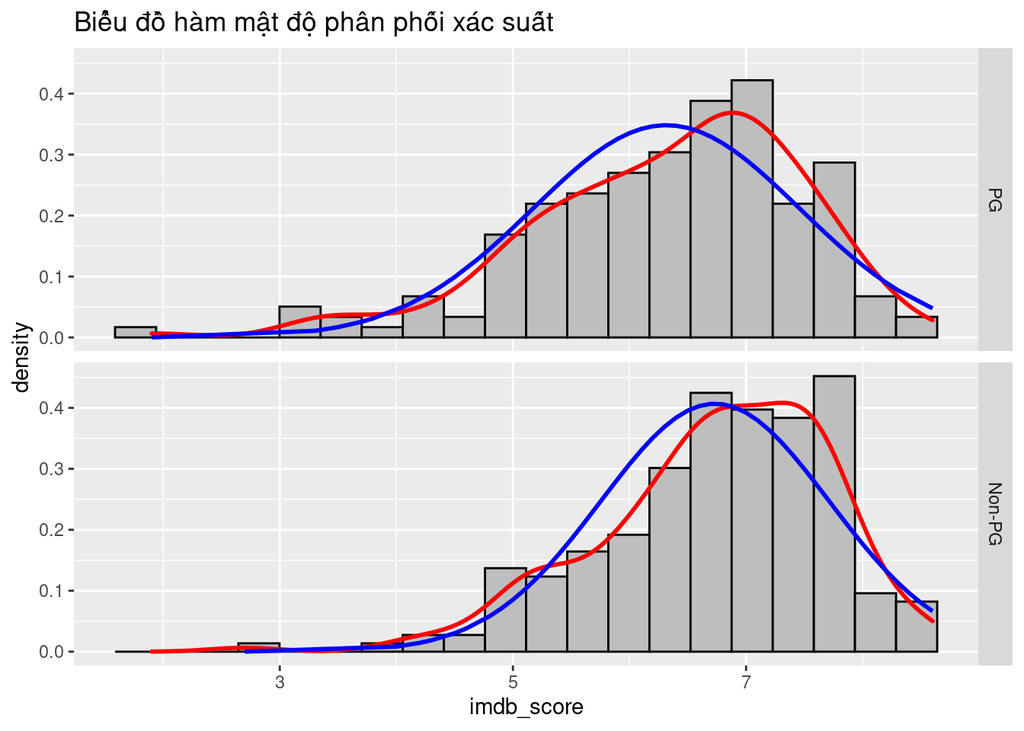

```r
mean_sample <- tapply(movie_metadata_sample_copy$imdb_score, movie_metadata_sample_copy$content_rating, mean)
#mean_sample
sd_sample <- tapply(movie_metadata_sample_copy$imdb_score, movie_metadata_sample_copy$content_rating, sd)
#sd_sample
movie_metadata_sample_copy$normal.density <- apply(movie_metadata_sample_copy,1, function(x){
  dnorm(as.numeric(x["imdb_score"]),
        mean_sample[x["content_rating"]], sd_sample[x["content_rating"]])})
ggplot(movie_metadata_sample_copy, aes(x = imdb_score)) +
  geom_histogram(aes(y = ..density..),
                 bins = 20,
                 fill = "grey", col = "black") +
  facet_grid(content_rating ~ .) +
  geom_density(col = "red", lwd = 1) +
  geom_line(aes(y = normal.density), col = "blue", lwd = 1) +
  ggtitle("Biểu đồ hàm mật độ phân phối xác suất")
```

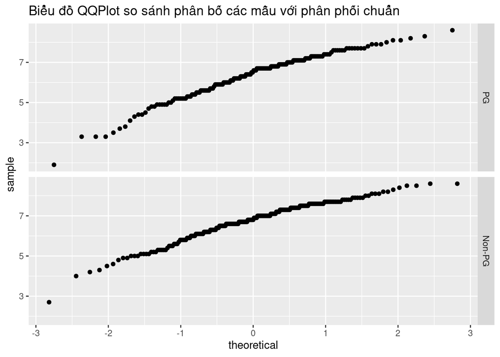

```r
movie_metadata_sample_copy$intercept <- apply(movie_metadata_sample_copy, 1, function(x){mean_sample[x["Category"]]})
movie_metadata_sample_copy$slope <- apply(movie_metadata_sample_copy, 1, function(x){sd_sample[x["Category"]]})
ggplot(movie_metadata_sample_copy, aes(sample = imdb_score)) +
  stat_qq() +
  facet_grid(content_rating ~ .) +
  geom_abline(data = movie_metadata_sample_copy, aes(intercept = intercept, slope = slope)) +
  ggtitle("Biểu đồ QQPlot so sánh phân bố các mẫu với phân phối chuẩn")
```

Tóm tắt dữ liệu Five number summary

```r
tapply(movie_metadata_sample_copy$imdb_score, movie_metadata_sample_copy$content_rating, summary)
```

```
## $PG
##    Min. 1st Qu.  Median    Mean 3rd Qu.    Max.
##   1.900   5.600   6.550   6.316   7.100   8.600
##
## $`Non-PG`
##    Min. 1st Qu.  Median    Mean 3rd Qu.    Max.
##   2.700   6.200   6.800   6.733   7.500   8.600
```

#### 5. Thống kê suy diễn

- Thống kê suy diễn này thuộc loại so sánh hai population mean.
- Phương pháp kiểm định phù hợp cho câu hỏi này là Awo sample t-test for two means.
- Xác định giả thuyết và đối thuyết:
  - Null hypothesis (Giả thuyết không - $H_0$): Không có sự khác biệt về điểm số của phim theo các đánh giá nội dung khác nhau
  - Alternative hypothesis (Đối thuyết - $H_A$): Tồn tại sự khác biệt về điểm số của các phim thepo các đánh giá nội dung khác nhau

#### 5.1. Tính t-statistics

```r
m1 <- mean(movie_metadata_sample_copy[movie_metadata_sample_copy$content_rating == "PG", "imdb_score"])
m2 <- mean(movie_metadata_sample_copy[movie_metadata_sample_copy$content_rating == "Non-PG", "imdb_score"])
n1 <- length(movie_metadata_sample_copy[movie_metadata_sample_copy$content_rating == "PG", "imdb_score"])
n2 <- length(movie_metadata_sample_copy[movie_metadata_sample_copy$content_rating == "Non-PG", "imdb_score"])
s1 <- sd(movie_metadata_sample_copy[movie_metadata_sample_copy$content_rating == "PG", "imdb_score"])
s2 <- sd(movie_metadata_sample_copy[movie_metadata_sample_copy$content_rating == "Non-PG", "imdb_score"])
se = sqrt(s1^2/n1 + s2^2/n2)
t = (m1 - m2)/se
t
```

```
## [1] -3.739081
```

#### 5.2. Tính p-value

```r
v = (s2^2/n2 + s1^2/n1)^2/((s1^2/n1)^2/(n1-1) + (s2^2/n2)^2/(n2-1))
p_value = 2*pt(q = t, df = v)
p_value
```

```
## [1] 0.0002176685
```

#### 5.3. Kiểm tra bằng t.test trong R

```r
t.test(movie_metadata_sample_copy$imdb_score ~ movie_metadata_sample_copy$content_rating, mu = 0, conf.level = 0.95,
       paired = FALSE, alternative = "two.sided", var.equal = FALSE)
```

```
##
##  Welch Two Sample t-test
##
## data:  movie_metadata_sample_copy$imdb_score by movie_metadata_sample_copy$content_rating
## t = -3.7391, df = 330.05, p-value = 0.0002177
## alternative hypothesis: true difference in means is not equal to 0
## 95 percent confidence interval:
##  -0.6367887 -0.1977351
## sample estimates:
##     mean in group PG mean in group Non-PG
##             6.316071             6.733333
```

### Câu hỏi 2: Ngôn ngữ có ảnh hưởng tới điểm đánh giá của phim hay không?

#### 1. Xem lướt qua dữ liệu

```r
nrow(movie_metadata_sample_copy[movie_metadata_sample_copy$language == "English",])
```

```
## [1] 351
```

```r
nrow(movie_metadata_sample_copy[movie_metadata_sample_copy$language != "English",])
```

```
## [1] 24
```

```r
tapply(movie_metadata_sample_copy$imdb_score, movie_metadata_sample_copy$language, summary)
```

```
## $Cantonese
##    Min. 1st Qu.  Median    Mean 3rd Qu.    Max.
##     6.7     7.0     7.3     7.1     7.3     7.3
##
## $Dutch
##    Min. 1st Qu.  Median    Mean 3rd Qu.    Max.
##     7.8     7.8     7.8     7.8     7.8     7.8
##
## $English
##    Min. 1st Qu.  Median    Mean 3rd Qu.    Max.
##   1.900   5.900   6.700   6.485   7.300   8.600
##
## $French
##    Min. 1st Qu.  Median    Mean 3rd Qu.    Max.
##   6.900   7.250   7.600   7.467   7.750   7.900
##
## $Hebrew
##    Min. 1st Qu.  Median    Mean 3rd Qu.    Max.
##       8       8       8       8       8       8
##
## $Hindi
##    Min. 1st Qu.  Median    Mean 3rd Qu.    Max.
##    7.40    7.55    7.70    7.70    7.85    8.00
##
## $Japanese
##    Min. 1st Qu.  Median    Mean 3rd Qu.    Max.
##    6.00    6.65    7.30    7.30    7.95    8.60
##
## $Mandarin
##    Min. 1st Qu.  Median    Mean 3rd Qu.    Max.
##   7.600   7.675   7.750   7.750   7.825   7.900
##
## $Norwegian
##    Min. 1st Qu.  Median    Mean 3rd Qu.    Max.
##     7.6     7.6     7.6     7.6     7.6     7.6
##
## $Persian
##    Min. 1st Qu.  Median    Mean 3rd Qu.    Max.
##     7.5     7.5     7.5     7.5     7.5     7.5
##
## $Portuguese
##    Min. 1st Qu.  Median    Mean 3rd Qu.    Max.
##     7.9     7.9     7.9     7.9     7.9     7.9
##
## $Spanish
##    Min. 1st Qu.  Median    Mean 3rd Qu.    Max.
##    6.80    7.50    7.50    7.42    7.60    7.70
##
## $Thai
##    Min. 1st Qu.  Median    Mean 3rd Qu.    Max.
##   6.600   6.725   6.850   6.850   6.975   7.100
```

Ta thấy kích thước hai mẫu con không tương tự nhau nên ta kết luận dataset này đã bị thiên vị về ngôn ngữ tiếng Anh nhiều hơn.